# Comparativa de Commodities y Activos Financieros

TP2 - Analisis Inteligente de Datos

Autor/a

Gustavo Calanchini

Fecha de publicación

8 de diciembre de 2024

## Introducción

En el presente trabajo, se planteó el desarrollo experimental de una aplicación Shiny que permita comparar valores relativos de algunos commodities y de algunos activos financieros llamados ETF´s.

Los ETF´s (Exchange Traded Fund) son activos financieros que se utilizan como elementos de inversion y ofrecen diversificación, liquidez y costos bajos.

El análisis comparativo de los valores relativos entre distintos ETF’s y commodities es de utilidad para mejorar la comprensión de dinámicas de mercados, identificar tendencias y evaluar riesgos de inversión, ademas permite dar una perspectiva sobre cómo se comportan diferentes activos en relación con otros al momento evaluar estrategias de inversion en términos de diversificación y cobertura.

## Selección de Datos

- Para la importación de información se realizó una búsqueda de los paquetes y funciones disponibles en [CRAN: Available Packages By Name](https://cran.r-project.org/web/packages/available_packages_by_name.html) que trabajen con datos financieros.
- Se eligió de allí para su uso el paquete ‘pdfetch’, que tiene varias funciones para obtener series históricas de datos económicos y financieros de fuentes públicas, como el sistema FRED de la FED de EEUU, Yahoo Finanzas, el Banco Mundial y la agencia Eurostat, entre otras. Información de este paquete en la carpeta Documentos.
- Los datos importados con este paquete son objetos XTS, que vienen con un componente index para indexar los datos temporalmente.
- Los ETF elegidos, siguen a un Indice que represente a algún tipo de actividad económica

Tabla de los ETF elegidos

| ETF | Nombre | Qué representa? |
| --- | --- | --- |
| GLD | SPDR Gold Shares | Valor internacional del Oro |
| SPY | S&P500 | Principales acciones de la bolsa de NY |
| IWM | Russell 2000 | Capitalización de las pequeñas empresas de EEUU |
| XLF | Financial Select Sector | Rendimiento de acciones del sector Financiero de EEUU |
| VNQ | Real State ETF | Capitalización de principales empresas del sector Inmobiliario de EEUU |
| GOVT | Treasury Bonds ETF | Rendimiento de Bonos del Tesoro de EEUU |
| VWO | Emerging Markets ETF | Acciones de empresas de alta, media y baja capitalización en mercados emergentes |
| ARKK | Innovation ETF | Rendimiento de empresas involucradas en innovación disruptiva |

- Los commodities que fueron seleccionados para tener una comparación entre algunas **materias primas**, **alimentos** y **energía** son los siguientes:

Tabla de los Commodities elegidos

| Reporte FED | Commodity | Unidad |
| --- | --- | --- |
| MCOILWTICO | Crude Oil (WTI) | *[USD/Barrel]* |
| PNGASEUUSDM | Global price of Natural gas | *[USD/Million Metric BTU (MMBTU)]* |
| PCOALAUUSDM | Global price of Coal | *[USD/Ton]* |
| PSOYBUSDM | Global price of Soybeans | *[USD/Ton]* |
| PWHEAMTUSDM | Global price of Wheat | *[USD/Ton]* |
| PCOTTINDUSDM | Global price of Cotton | *[Cents/Pound]* |
| PIORECRUSDM | Global price of Iron Ore | *[USD/Ton]* |
| PCOPPUSDM | Global price of Copper | *[USD/Ton]* |
| APU0000702111 | Average Price US: Bread, White, Pan | *[USD/Pound]* |
| PBEEFUSDM | Global price of Beef | *[Cents/Pound]* |
| APU0000FF1101 | Average Price US: Chicken Breast, Boneless | *[USD/Pound]* |
| PBANSOPUSDM | Global price of Bananas | *[USD/Ton]* |
| PRICENPQUSDM | Global price of Rice | *[USD/Ton]* |
| PSUGAISAUSDM | Global price of Sugar | *[Cents/Pound]* |
| PCOCOUSDM | Global price of Cocoa | *[USD/Ton]* |
| PPOULTUSDM | Global price of Poultry | *[Cents/Pound]* |
| PWOOLFUSDM | Global price of Wool | *[USD/Kg]* |
| PFISHUSDM | Global price of Fish Meal | *[USD/Ton]* |
| PORANGUSDM | Global price of Orange | *[USD/Pound]* |
| PPORKUSDM | Global price of Swine | *[Cents/Pound]* |

## Limpieza de Datos

El trabajo se estructuró en dos archivos de R separados, uno para importar y organizar los datos (llamado *“Codigo_TP2.R”*) y que los guarda en *“baseDatosTP2.rds”* para que lo pueda acceder el otro archivo que es la app de Shiny (llamado *“app.R”*) para que los pueda cargar y realizar la visualización.

Los datos importados con las funciones del paquete ‘pdfetch’ son objetos XTS. Éstos objetos vienen con un componente Index para indexar los datos temporalmente. Éstos objetos luego son convertidos a data frame para facilitar la limpieza y organización de los datos, principalmente las fechas.

##### Importacion Datos

- Se trabajó en bases de tiempo mensuales y para los activos financieros se eligieron los valores de cierre en la cotización.

```r
# Librerías a utilizar ----
library(tidyverse)
library(pdfetch) # para funciones de importar datos de FRED y Yahoo Finance
library(xts) # para tratar con datos xts
```

```r
# Importación de datos de los commodities ----
df_commodities_xts <- merge(
  pdfetch_FRED("MCOILWTICO"), pdfetch_FRED("PNGASEUUSDM"),
  pdfetch_FRED("PCOALAUUSDM"), pdfetch_FRED("PSOYBUSDM"),
  pdfetch_FRED("PWHEAMTUSDM"), pdfetch_FRED("PCOTTINDUSDM"),
  pdfetch_FRED("PIORECRUSDM"), pdfetch_FRED("PCOPPUSDM"),
  pdfetch_FRED("APU0000702111"), pdfetch_FRED("PBEEFUSDM"),
  pdfetch_FRED("APU0000FF1101"), pdfetch_FRED("PBANSOPUSDM"),
  pdfetch_FRED("PRICENPQUSDM"), pdfetch_FRED("PSUGAISAUSDM"),
  pdfetch_FRED("PCOCOUSDM"), pdfetch_FRED("PPOULTUSDM"),
  pdfetch_FRED("PWOOLFUSDM"), pdfetch_FRED("PFISHUSDM"),
  pdfetch_FRED("PORANGUSDM"), pdfetch_FRED("PPORKUSDM")
)
```

```r
# Importación de los datos de ETF´s ----
df_etf_xts <- merge(
  pdfetch_YAHOO("GLD", from = "1990-01-01", field = "close", interval = "monthly"),
  pdfetch_YAHOO("SPY", from = "1990-01-01", field = "close", interval = "monthly"),
  pdfetch_YAHOO("IWM", from = "1990-01-01", field = "close", interval = "monthly"),
  pdfetch_YAHOO("XLF", from = "1990-01-01", field = "close", interval = "monthly"),
  pdfetch_YAHOO("VNQ", from = "1990-01-01", field = "close", interval = "monthly"),
  pdfetch_YAHOO("GOVT", from = "1990-01-01", field = "close", interval = "monthly"),
  pdfetch_YAHOO("VWO", from = "1990-01-01", field = "close", interval = "monthly"),
  pdfetch_YAHOO("ARKK", from = "1990-01-01", field = "close", interval = "monthly")
)
```

- Para facilitar su posterior comprensión se renombrar las variables

```r
# Organización de los Datos ----
nombres_commodities <- c(
  "Petroleo", "Gas", "Carbon", "Soja", "Trigo", "Algodon",
  "Hierro", "Cobre", "Pan", "Carne", "Pollo_usa", "Banana",
  "Arroz", "Azucar", "Cacao", "Carne_ave", "Lana", "Pescado",
  "Naranja", "Cerdo"
)
colnames(df_commodities_xts) <- nombres_commodities

nombres_etf <- c(
  "Oro", "S&P 500", "Russell 2000", "Financiero", "Real State", "Bonos del Tesoro",
  "Mercados Emergentes", "Innovacion"
)
colnames(df_etf_xts) <- nombres_etf
```

- Se convierte el tipo de data frame, se igualan las fechas al primer día del mes, ya que los diferentes datos vienen publicados en diferentes días del mes. Luego se unifica la base de datos y se guarda en el archivo *“baseDatosTP2.rds”* para que quede disponible para la aplicación de Shiny.

```r
# Conversión del tipo de data frame ----
# Se redondean las fechas para abajo en cada data frame antes del merge

df_commodities <- fortify.zoo(df_commodities_xts)
df_commodities <- mutate(df_commodities,
  Index = floor_date(Index, "month")
)

df_etf <- fortify.zoo(df_etf_xts)
df_etf <- mutate(df_etf,
  Index = floor_date(Index, "month")
)
# Se unifican los datos
df <- merge(df_commodities, df_etf)

# se guardan en un archivo
saveRDS(df, file = "baseDatosTP2.rds")
```

## Aplicacion Shiny

##### Preparacion de datos

- Carga de librerías a utilizar

```r
#  Librerías a utilizar  ----
library(shiny)
library(tidyverse)
library(plotly)
library(bslib)
```

- Importación de la base de datos

```r
# Importación de la base de datos ----
base_datos <- readRDS("baseDatosTP2.rds")
```

- Se realiza una selección de las opciones a utilizar en las comparaciones relativas (se usan los nombres de las variables)

```r
# Listado de los commodities y activos financieros disponibles ----
opciones_commodity <- base_datos |>
  select(!contains("Index")) |>
  colnames() |>
  sort()
```

###### Definicion de la Interfaz de Usuario

En esta se diseña la apariencia visual de la aplicación con la que interactúan los usuarios.

La etapa UI se define con la función **fillPage()** utilizado bs_theme() con un tema “darkly” de Bootswatch para lograr la estética de un diseño oscuro, y dentro de fillPage() se usan las funciones **sidebarLayout()** para la organización de los elementos **sliderInput()** y **selectInput()** para los controles de entrada. También se define el elemento de salida **mainPanel()** con el gráfico **plotlyOutput()**.

```r
# Definición de la Interfaz de Usuario ----
ui <- fillPage(
  theme = bs_theme(
    version = 5, # Usar la versión más reciente de Bootstrap 5
    bootswatch = "darkly", # Tema oscuro de Bootswatch
    primary = "#FF7F27" # Color principal (anaranjado)
  ),

  titlePanel("Comparador de Commodities y Activos Financieros",
             windowTitle = "Commodities Comparator"), # Titulo de la aplicación Shiny

  sidebarLayout(
    position = "right",

    sidebarPanel(
      class = "sidebar",
      sliderInput(
        inputId = "rangoFechas", # ID del widget
        label = "Rango de Fechas: ", # Título a mostrar en la app
        value = c(ymd("2010-01-01"), as_date(today())), # Valor seleccionado inicialmente
        min = min(base_datos$Index), # Mínimo valor posible
        max = max(base_datos$Index), # Máximo valor posible
        timeFormat = "%b-%y"
      ),

      selectInput(
        inputId = "commodity1", # ID del widget
        label = "Seleccione el 1er Commodity (Numerador): ", # Selección del Commodity
        choices = opciones_commodity, # Opciones disponibles
      ),

      selectInput(
        inputId = "commodity2", # ID del widget
        label = "Seleccione el 2do Commodity (Denominador): ", # Selección del Commodity
        choices = opciones_commodity, # Opciones disponibles
      )
    ),

    mainPanel(
      class = "main",
      plotlyOutput(outputId = "MiGrafico")
    )
  )
)
```

###### Definicion de la etapa Server

Esta es la etapa de la aplicación Shiny que contiene el código para procesar las entradas del usuario que se reciben a través de la UI, se procesan, se realizan cálculos y se generan las salidas que se muestran en la interfaz de usuario, respondiendo a las acciones del usuario y actualizando la UI de forma dinámica.

- Primero se definen una serie de objetos reactivos, los que son para la selección del usuario de los datos a comparar, el del rango de fechas y el de el título a presentar en el gráfico.
- Continua la llamada al gráfico que es la salida elegida para esta aplicación.
- Dentro de esta llamada se realizan los calculo para generar las salidas:
  - Se filtran las fechas que están dentro del rango seleccionado
  - Se realiza la comparativa relativa entre los commodities seleccionados
  - Se construye un texto para el gráfico dinámico de Plotly
- Por ultimo se llama al gráfico de Plotly

```r
# Definicion del Server ----
server <- function(input, output, session) {
  # Inputs de datos reactivos
  commodity1_reactivo <- reactive({
    input$commodity1
  })
  commodity2_reactivo <- reactive({
    input$commodity2
  })
  fechas_reactivo <- reactive({
    input$rangoFechas
  })
  titulo_reactivo <- reactive({
    paste0(
      "Valor de ",
      str_to_upper(commodity1_reactivo()), " medido en unidades de ",
      str_to_upper(commodity2_reactivo()), " entre: ",
      paste0(format.Date(fechas_reactivo(), "%b %Y",
                        date_names = "es"),
             collapse = " - ")
    )
  })

  output$MiGrafico <- renderPlotly({
    grafico <- base_datos |>
      filter(
        Index >= fechas_reactivo()[1],
        Index <= fechas_reactivo()[2],
        !is.na(get(commodity1_reactivo())) | !is.na(get(commodity2_reactivo()))
      ) |>
      mutate(
        relacion = get(commodity1_reactivo()) / get(commodity2_reactivo()),
        texto = paste0(
          "<b>Valor: </b>", round(relacion, digits = 4), "<br>",
          "<b>Fecha: </b>", format.Date(Index, "%b%y"), "<br>"
        )
      ) |>
      filter(!is.na(relacion) & !is.infinite(relacion)) |>
      ggplot(
        #En aes se define group para que funcione geom_line()
        aes(x = Index, y = relacion, text = texto, group = 1)) +
      geom_point(size = 0.5, colour = "yellow") +
      geom_line(size = 0.6, colour = "#FF7F27") +
      labs(
        title = titulo_reactivo()
      ) +
      scale_y_continuous(name = "Relacion") +
      scale_x_date(name = "", date_labels = "%b-%y") +
      theme_minimal()+
      theme(
        plot.background = element_rect(fill = "black", color = NA),
        panel.background = element_rect(fill = "black", color = NA),
        panel.grid = element_line(color = "gray"),
        plot.title = element_text(color = "white"),
        axis.text = element_text(color = "white"),
        axis.title = element_text(color = "white"),
        legend.position = "none"
      ) # Sobre el tema minimal se personalizan los elementos del gráfico

    ggplotly(grafico, tooltip = "text")
  })
}
```

###### Ejecucion de la Aplicacion

Por ultimo se ejecuta la aplicación

```r
# Ejecución de aplicación ----
shinyApp(ui = ui, server = server)
```

## Resultados

A continuación se muestra una imagen de la aplicación experimental desarrollada.

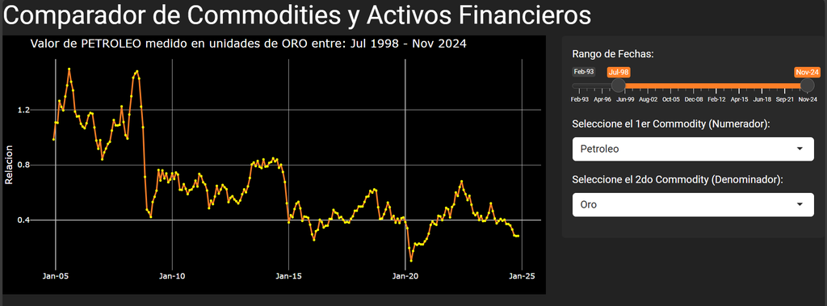

Imagen de la aplicacion Shiny

## Conclusiones

- Una de las principales dificultades encontradas estuvo en conseguir datos útiles. Si bien existen diversas fuentes de datos públicos, no resultó fácil dar con los datos pretendidos.
- **Próximos pasos:**
  - Se podrían agregar otros indicadores económicos de distintas regiones como ingresos promedio, valor de inmuebles y tipos de cambio de monedas.
  - Aplicar clustering de una selección de activos financieros para segmentar por correlación, para poder hacer carteras diversificadas, es decir, con activos no conrrelacionadas.

## Apéndice

A continuacion se plantea una evaluación de la utilidad de la aplicación.

#### Evaluacion de la utilidad de la aplicacion.

El análisis comparativo de los precios relativos entre **ETF’s** y **commodities** proporciona información sobre la diversificación y el riesgo, permitiendo a inversores tomar decisiones cómo ajustar sus carteras de inversión.

#### 1. **Diversificación y Estrategias de Cobertura:**

Una practica recomendada es diversificar inversiones para reducir el riesgo en el portfolio, tener una menor volatilidad, y para esto necesario incluir activos con correlaciones bajas entre sí. Evaluar precios relativos entre **ETF’s** y **commodities** ayuda a identificar posibles relaciones entre activos. Por ejemplo, el ETF **GLD** (que sigue el precio del oro) y commodities como **Petróleo** o **cobre** suelen tener correlaciones diferentes a los índices de acciones representados por **SPY** (S&P 500) o **IWM** (Russell 2000).

Los ETF’s como **VNQ** (sector inmobiliario) o **XLF** (sector financiero) tienen comportamientos que suelen estar más relacionados con la economía en general, mientras que commodities como **Soja**, **Trigo** o **Carne** pueden ser más sensibles a factores como el clima y la oferta y demanda global.

Analizar cómo el comportamiento de estos activos en conjunto permite desarrollar **estrategias de cobertura** más eficientes, protegiendo a inversores de posibles movimientos adversos en los mercados.

#### 2. **Correlaciones y Tendencias de Mercado:**

Estudiar las correlaciones, tendencias y dinámicas de distintos activos permite comprender mejor los factores macroeconómicos que afectan los mercados y desarrollar estrategias de inversión más efectivas. Por ejemplo, los precios de commodities como **Petróleo** o **Gas** suelen depender de factores geopolíticos y la oferta global, mientras que ETFs como **SPY** responden a políticas monetarias y fiscales en EE.UU. Comparando tendencias, se pueden identificar momentos favorables para invertir en commodities o ETFs, según los factores macroeconómicos. Un análisis de correlación entre **Petróleo** y **XLF** puede revelar el impacto del petróleo en el sector financiero, y la relación entre **Soja** y **VWO** muestra cómo las materias primas afectan los mercados emergentes.

#### 3. **Condiciones Macroeconómicas y Factores Externos:**

Commodities como **Trigo**, **Azúcar** o **Cacao** son afectados como el clima, políticas agrícolas y comerciales, mientras que ETF’s ligados a acciones, como **SPY** o el **ARKK** (innovaciones disruptivas), responden principalmente a expectativas de crecimiento económico y tasas de interés.

#### 4. **Evaluación del Riesgo y Oportunidades de Inversión:**

El análisis de precios relativos entre commodities y ETFs permite evaluar riesgos de inversión. Por ejemplo, el **GLD**, como activo refugio, se compara con commodities como **Petróleo** o **Carne** para ajustar los portafolios según las condiciones económicas. ETFs como **ARKK**, más volátiles y enfocados en tecnología disruptiva, pueden balancearse con commodities como **Hierro** o **Cobre** para manejar el riesgo y optimizar las inversiones según las proyecciones globales.

#### 5. **Impacto de Factores Globales:**

Los precios de los commodities son fuertemente influenciados por factores globales como conflictos geopolíticos y políticas de productores. Comparar ETF’s como **VNQ** (bienes raices) o **VWO** (mercados emergentes) puede ayudar a identificar desconexiones entre los mercados de commodities y acciones, señalando posibles oportunidades o riesgos.

#### 6. **Análisis Fundamental y Técnico:**

La comparación entre ETF’s y commodities proporciona información valiosa para el análisis **fundamental** (oferta y demanda subyacentes) y **técnico** (tendencias y patrones de precios). Por ejemplo, un análisis técnico entre **Cobre** y el ETF **SPY** puede indicar las expectativas de crecimiento industrial y el comportamiento de las acciones en el S&P 500.